# Customer Behaviour Visual Data Story

## Overview of the Observational Dataset

This project analyses customer behaviour using observational data collected through a Google Form. The goal is to identify purchasing trends, payment methods, and group dynamics across time and day.

## Purchases by Day of the Week

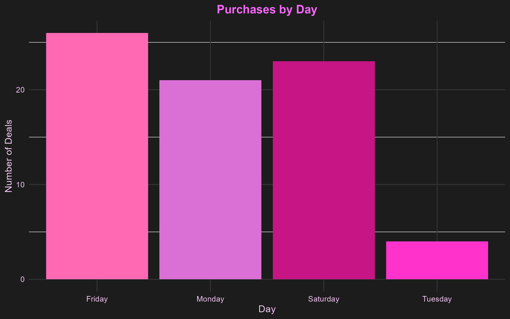

*This bar chart shows which days of the week had the most purchases. This is overall helpful to identify when it is needed to have extra staff working.*

## Distribution of Payment Methods

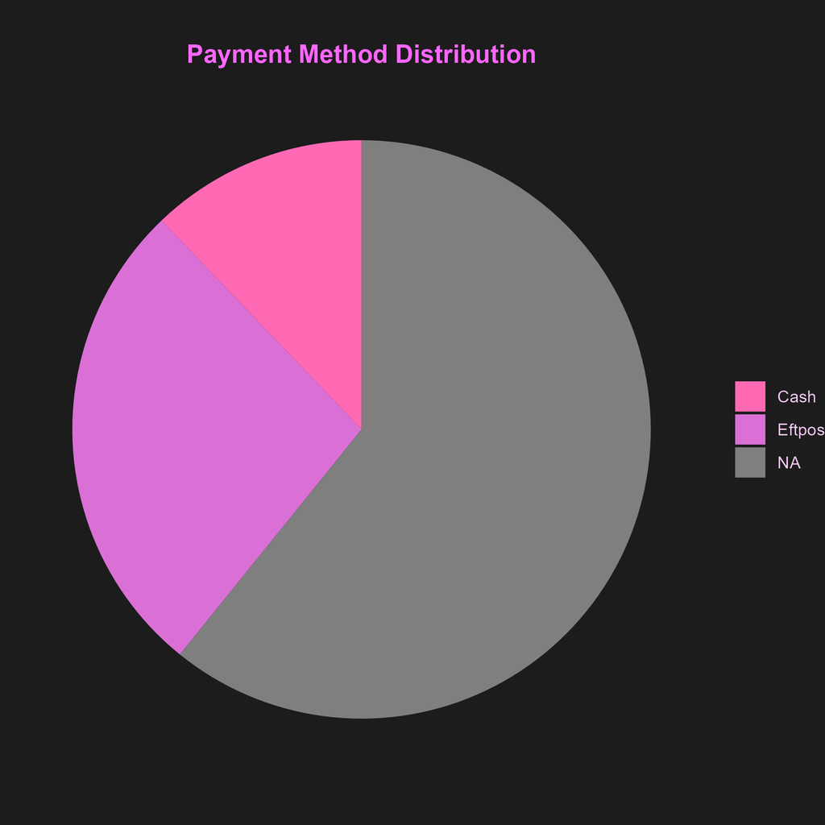

*This pie chart presents the overall distribution of payment methods used by customers. However there is a mistake which I later fixed with another “plot 4”. The Issue is that my previously collected data did not contain the different payment option question and was later added when revisiting the project.*

## Purchases by Time of Day (30-Minute Intervals)

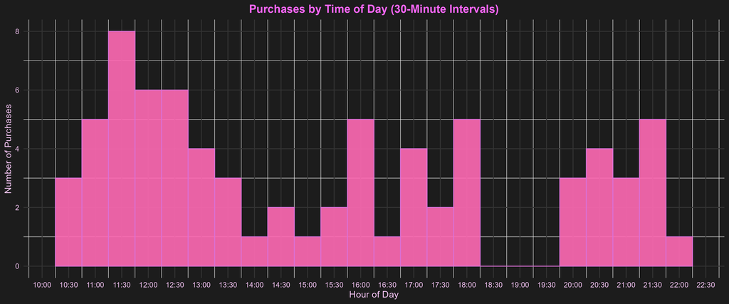

*This histogram reveals when purchases tend to occur most frequently throughout the day. Very helpful to understand trends throughout the day.*

## Payment Method Distribution (Newer Observations Only)

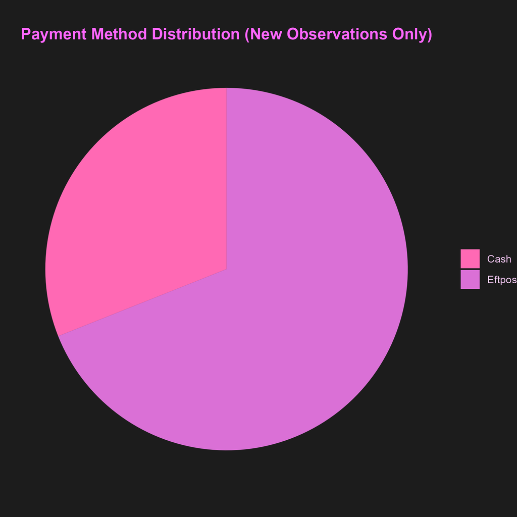

*This chart filters the data to show payment methods starting from the 46th recorded purchase. As I had spoken before this only includes the newer data which was collected with this question in mind.*

[figure not shown]

## Payment Method Trends Over Time